# Assignment -1

### iii. Produce side-by-side boxplots of Outstate versus Private

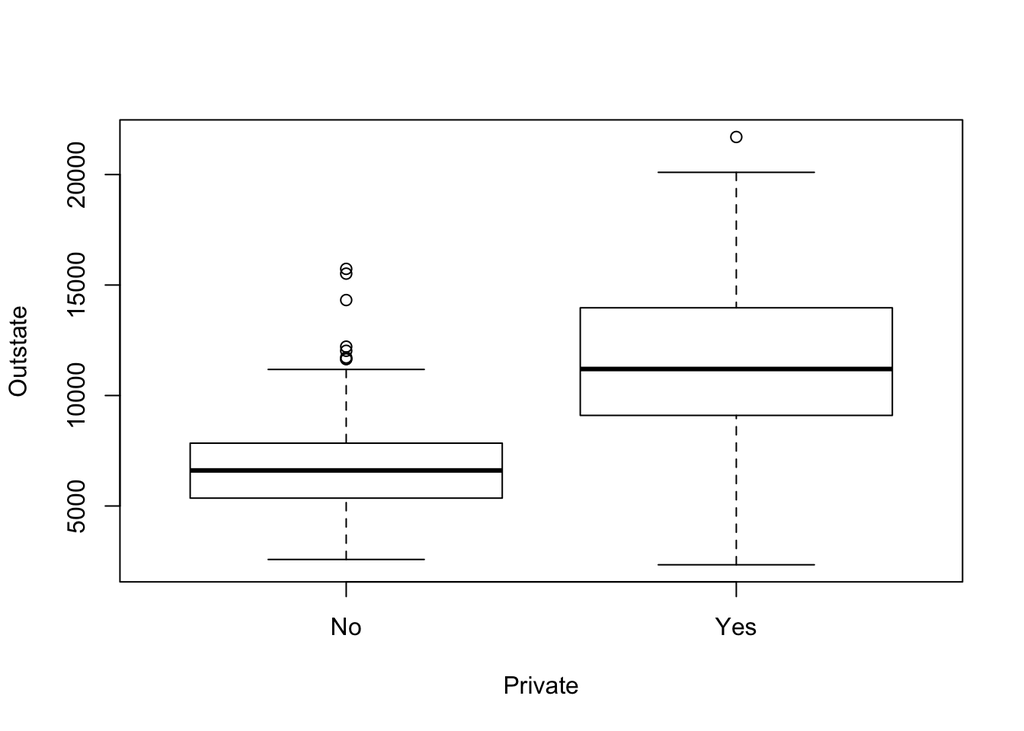

```r
# produce side-by-side boxplots of Outstate versus Privat

#using plot
plot(college$Private,college$Outstate,xlab="Private",ylab = "Outstate")

#using boxplot
boxplot(Outstate~Private,data=college, xlab="Private",ylab = "Outstate")
```

```r
#Divide universities into two groups based on whether or not
#the proportion of students coming from the top 10% of their high school classes exceeds 50 %.

Elite = rep("No",nrow(college))
Elite[college$Top10perc >50]="Yes"
Elite=as.factor(Elite)
college=data.frame(college ,Elite)

summary(college)
```

```
##  Private        Apps           Accept          Enroll       Top10perc
##  No :212   Min.   :   81   Min.   :   72   Min.   :  35   Min.   : 1.00
##  Yes:565   1st Qu.:  776   1st Qu.:  604   1st Qu.: 242   1st Qu.:15.00
##            Median : 1558   Median : 1110   Median : 434   Median :23.00
##            Mean   : 3002   Mean   : 2019   Mean   : 780   Mean   :27.56
##            3rd Qu.: 3624   3rd Qu.: 2424   3rd Qu.: 902   3rd Qu.:35.00
##            Max.   :48094   Max.   :26330   Max.   :6392   Max.   :96.00
##    Top25perc      F.Undergrad     P.Undergrad         Outstate
##  Min.   :  9.0   Min.   :  139   Min.   :    1.0   Min.   : 2340
##  1st Qu.: 41.0   1st Qu.:  992   1st Qu.:   95.0   1st Qu.: 7320
##  Median : 54.0   Median : 1707   Median :  353.0   Median : 9990
##  Mean   : 55.8   Mean   : 3700   Mean   :  855.3   Mean   :10441
##  3rd Qu.: 69.0   3rd Qu.: 4005   3rd Qu.:  967.0   3rd Qu.:12925
##  Max.   :100.0   Max.   :31643   Max.   :21836.0   Max.   :21700
##    Room.Board       Books           Personal         PhD
##  Min.   :1780   Min.   :  96.0   Min.   : 250   Min.   :  8.00
##  1st Qu.:3597   1st Qu.: 470.0   1st Qu.: 850   1st Qu.: 62.00
##  Median :4200   Median : 500.0   Median :1200   Median : 75.00
##  Mean   :4358   Mean   : 549.4   Mean   :1341   Mean   : 72.66
##  3rd Qu.:5050   3rd Qu.: 600.0   3rd Qu.:1700   3rd Qu.: 85.00
##  Max.   :8124   Max.   :2340.0   Max.   :6800   Max.   :103.00
##     Terminal       S.F.Ratio      perc.alumni        Expend
##  Min.   : 24.0   Min.   : 2.50   Min.   : 0.00   Min.   : 3186
##  1st Qu.: 71.0   1st Qu.:11.50   1st Qu.:13.00   1st Qu.: 6751
##  Median : 82.0   Median :13.60   Median :21.00   Median : 8377
##  Mean   : 79.7   Mean   :14.09   Mean   :22.74   Mean   : 9660
##  3rd Qu.: 92.0   3rd Qu.:16.50   3rd Qu.:31.00   3rd Qu.:10830
##  Max.   :100.0   Max.   :39.80   Max.   :64.00   Max.   :56233
##    Grad.Rate      Elite
##  Min.   : 10.00   No :699
##  1st Qu.: 53.00   Yes: 78
##  Median : 65.00
##  Mean   : 65.46
##  3rd Qu.: 78.00
##  Max.   :118.00
```

```r
summary(Elite)
```

```
##  No Yes
## 699  78
```

### iv. Produce side-by-side boxplots of Outstate versus Elite

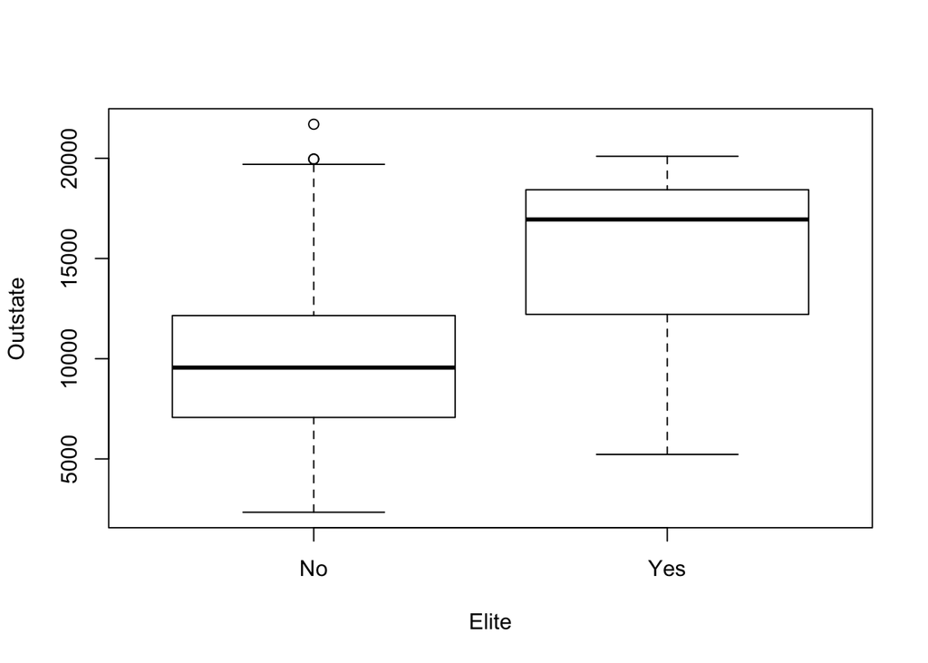

```r
#produce side-by-side boxplots of Outstate versus Elite
plot(college$Elite,college$Outstate,xlab="Elite",ylab="Outstate")
```

### v. Produce some histograms with differing numbers of bins for a few of the quantitative variables

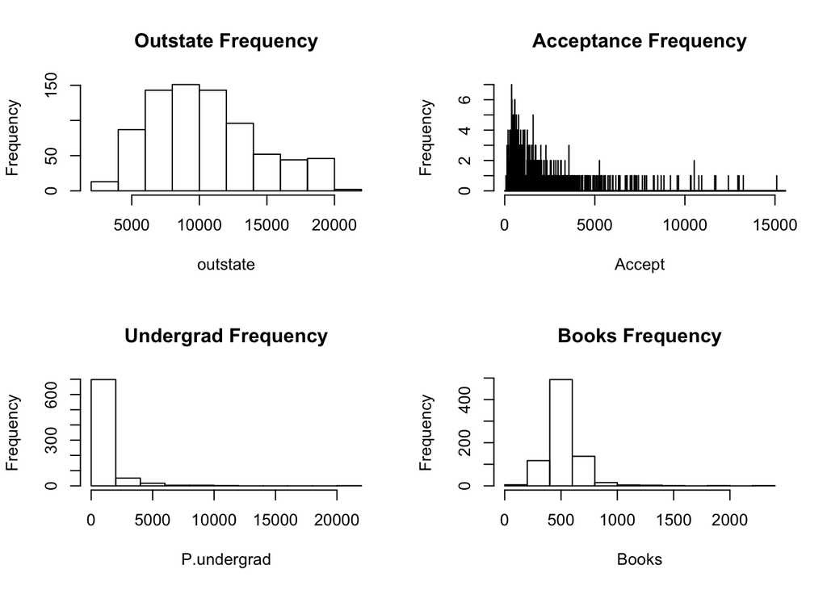

```r
#produce some histograms with differing numbers of bins for a few of the quantitative variables
par(mfrow=c(2,2))
hist(college$Outstate,xlab = "outstate", main = "Outstate Frequency", breaks = 10)
hist(college$Accept,xlab = "Accept", xlim=c(0,15000),breaks =seq(0,max(college$Accept),5), main = "Acceptance Frequency")
hist(college$P.Undergrad,xlab = "P.undergrad", main = "Undergrad Frequency")
hist(college$Books,xlab = "Books", main = "Books Frequency")
```

### vi. Brief summary of what you discover?

```r
str(college)
```

```
## 'data.frame':    777 obs. of  19 variables:
##  $ Private    : Factor w/ 2 levels "No","Yes": 2 2 2 2 2 2 2 2 2 2 ...
##  $ Apps       : num  1660 2186 1428 417 193 ...
##  $ Accept     : num  1232 1924 1097 349 146 ...
##  $ Enroll     : num  721 512 336 137 55 158 103 489 227 172 ...
##  $ Top10perc  : num  23 16 22 60 16 38 17 37 30 21 ...
##  $ Top25perc  : num  52 29 50 89 44 62 45 68 63 44 ...
##  $ F.Undergrad: num  2885 2683 1036 510 249 ...
##  $ P.Undergrad: num  537 1227 99 63 869 ...
##  $ Outstate   : num  7440 12280 11250 12960 7560 ...
##  $ Room.Board : num  3300 6450 3750 5450 4120 ...
##  $ Books      : num  450 750 400 450 800 500 500 450 300 660 ...
##  $ Personal   : num  2200 1500 1165 875 1500 ...
##  $ PhD        : num  70 29 53 92 76 67 90 89 79 40 ...
##  $ Terminal   : num  78 30 66 97 72 73 93 100 84 41 ...
##  $ S.F.Ratio  : num  18.1 12.2 12.9 7.7 11.9 9.4 11.5 13.7 11.3 11.5 ...
##  $ perc.alumni: num  12 16 30 37 2 11 26 37 23 15 ...
##  $ Expend     : num  7041 10527 8735 19016 10922 ...
##  $ Grad.Rate  : num  60 56 54 59 15 55 63 73 80 52 ...
##  $ Elite      : Factor w/ 2 levels "No","Yes": 1 1 1 2 1 1 1 1 1 1 ...
```

```r
summary(college$Grad.Rate)
```

```
##    Min. 1st Qu.  Median    Mean 3rd Qu.    Max.
##   10.00   53.00   65.00   65.46   78.00  118.00
```

From summary of dataset we can see graduation rate maximum value is **118** which seems weird as the percentage cannot be greater than 100.

```r
gradrate_max_data <- college[college$Grad.Rate == 118, ]
nrow(gradrate_max_data)
```

```
## [1] 1
```

```r
rownames(gradrate_max_data)
```

```
## [1] "Cazenovia College"
```

### Question 10: Boston Dataset

### a) How many rows are in this data set? How many columns? What do the rows and columns represent?

```r
library(MASS)
?Boston

head(Boston)
```

```
##      crim zn indus chas   nox    rm  age    dis rad tax ptratio  black
## 1 0.00632 18  2.31    0 0.538 6.575 65.2 4.0900   1 296    15.3 396.90
## 2 0.02731  0  7.07    0 0.469 6.421 78.9 4.9671   2 242    17.8 396.90
## 3 0.02729  0  7.07    0 0.469 7.185 61.1 4.9671   2 242    17.8 392.83
## 4 0.03237  0  2.18    0 0.458 6.998 45.8 6.0622   3 222    18.7 394.63
## 5 0.06905  0  2.18    0 0.458 7.147 54.2 6.0622   3 222    18.7 396.90
## 6 0.02985  0  2.18    0 0.458 6.430 58.7 6.0622   3 222    18.7 394.12
##   lstat medv
## 1  4.98 24.0
## 2  9.14 21.6
## 3  4.03 34.7
## 4  2.94 33.4
## 5  5.33 36.2
## 6  5.21 28.7
```

```r
Boston[1,]
```

```
##      crim zn indus chas   nox    rm  age  dis rad tax ptratio black lstat
## 1 0.00632 18  2.31    0 0.538 6.575 65.2 4.09   1 296    15.3 396.9  4.98
##   medv
## 1   24
```

```r
nrow(Boston)
```

```
## [1] 506
```

```r
ncol(Boston)
```

```
## [1] 14
```

```r
dim(Boston)
```

```
## [1] 506  14
```

```r
summary(Boston)
```

```
##       crim                zn             indus            chas
##  Min.   : 0.00632   Min.   :  0.00   Min.   : 0.46   Min.   :0.00000
##  1st Qu.: 0.08204   1st Qu.:  0.00   1st Qu.: 5.19   1st Qu.:0.00000
##  Median : 0.25651   Median :  0.00   Median : 9.69   Median :0.00000
##  Mean   : 3.61352   Mean   : 11.36   Mean   :11.14   Mean   :0.06917
##  3rd Qu.: 3.67708   3rd Qu.: 12.50   3rd Qu.:18.10   3rd Qu.:0.00000
##  Max.   :88.97620   Max.   :100.00   Max.   :27.74   Max.   :1.00000
##       nox               rm             age              dis
##  Min.   :0.3850   Min.   :3.561   Min.   :  2.90   Min.   : 1.130
##  1st Qu.:0.4490   1st Qu.:5.886   1st Qu.: 45.02   1st Qu.: 2.100
##  Median :0.5380   Median :6.208   Median : 77.50   Median : 3.207
##  Mean   :0.5547   Mean   :6.285   Mean   : 68.57   Mean   : 3.795
##  3rd Qu.:0.6240   3rd Qu.:6.623   3rd Qu.: 94.08   3rd Qu.: 5.188
##  Max.   :0.8710   Max.   :8.780   Max.   :100.00   Max.   :12.127
##       rad              tax           ptratio          black
##  Min.   : 1.000   Min.   :187.0   Min.   :12.60   Min.   :  0.32
##  1st Qu.: 4.000   1st Qu.:279.0   1st Qu.:17.40   1st Qu.:375.38
##  Median : 5.000   Median :330.0   Median :19.05   Median :391.44
##  Mean   : 9.549   Mean   :408.2   Mean   :18.46   Mean   :356.67
##  3rd Qu.:24.000   3rd Qu.:666.0   3rd Qu.:20.20   3rd Qu.:396.23
##  Max.   :24.000   Max.   :711.0   Max.   :22.00   Max.   :396.90
##      lstat            medv
##  Min.   : 1.73   Min.   : 5.00
##  1st Qu.: 6.95   1st Qu.:17.02
##  Median :11.36   Median :21.20
##  Mean   :12.65   Mean   :22.53
##  3rd Qu.:16.95   3rd Qu.:25.00
##  Max.   :37.97   Max.   :50.00
```

Each row represents particular suburb(neighborhood) data from Boston city. Every column shows different factors showing the crime:  
crim: per capita crime rate by town  
zn proportion of residential land zoned for lots over 25,000 sq. Ft  
indus proportion of non-retail business acres per town.  
chas Charles River dummy variable (= 1 if tract bounds river; 0 otherwise)  
nox nitrogen oxides concentration (parts per 10 million)  
rm average number of rooms per dwelling  
age proportion of owner-occupied units built prior to 1940  
dis weighted mean of distances to five Boston employment centers  
rad index of accessibility to radial highways  
tax full-value property-tax rate per $10,000  
ptratio pupil-teacher ratio by town  
black 1000(Bk - 0.63)^2 where Bk is the proportion of blacks by town  
lstat lower status of the population (percent)  
medv median value of owner-occupied homes in $1000s

### b) Pairwise scatterplots:

crime chas nox age

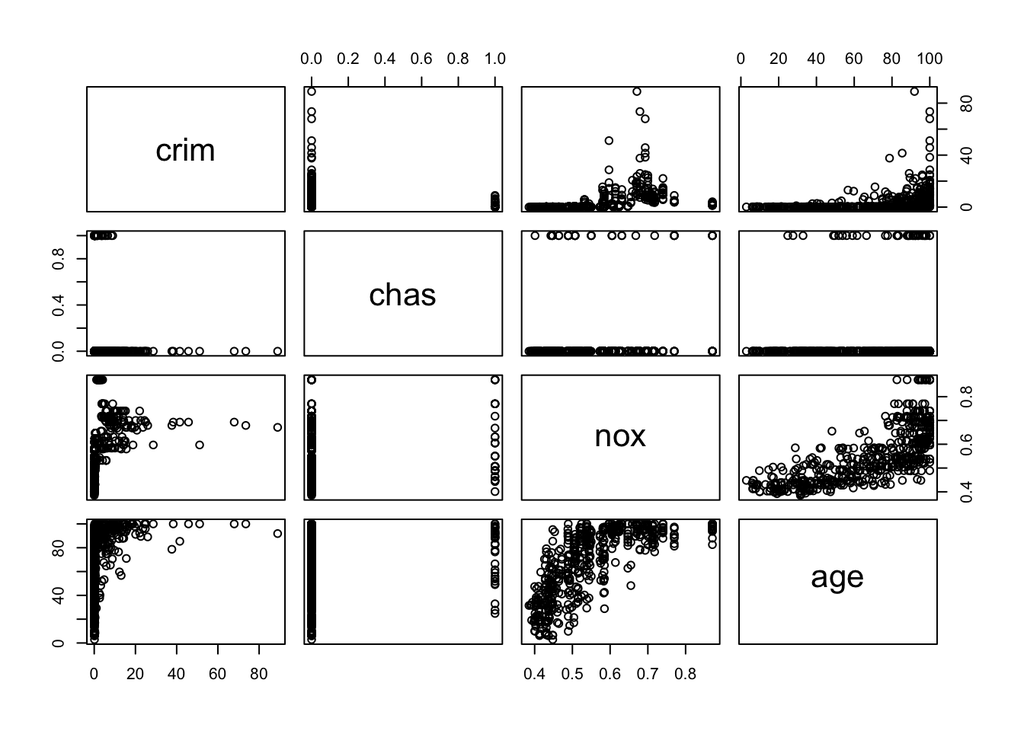

```r
?pairs
pairs(~crim+chas+nox+age, data=Boston)
```

### Check Correlation between all variables

**Are any of the predictors associated with per capita crime rate? If so, explain the relationship.**

As the ‘proportion of houses with more age of property’ increases ‘crime rate per capita’ starts increasing from ‘20 to 30’ As the nox(nitrogen oxide concentration) increases above 0.4, ‘crime per capita’ starts increasing and stops at 0.7 When the suburb is bound by Charles river i.e. chas is 1, it has low crime per capita

### c) Are any of the predictors associated with per capita crime rate? If so, explain the relationship. Based on correlation output, there is relationship between crim and other predictors

```r
?cor
cor(Boston, use="everything")[1,]
```

```
##        crim          zn       indus        chas         nox          rm
##  1.00000000 -0.20046922  0.40658341 -0.05589158  0.42097171 -0.21924670
##         age         dis         rad         tax     ptratio       black
##  0.35273425 -0.37967009  0.62550515  0.58276431  0.28994558 -0.38506394
##       lstat        medv
##  0.45562148 -0.38830461
```

### d) Do any of the suburbs of Boston appear to have particularly high crime rates? Tax rates? Pupil-teacher ratios? Comment on the range of each predictor.

```r
summary(Boston)
```

```
##       crim                zn             indus            chas
##  Min.   : 0.00632   Min.   :  0.00   Min.   : 0.46   Min.   :0.00000
##  1st Qu.: 0.08204   1st Qu.:  0.00   1st Qu.: 5.19   1st Qu.:0.00000
##  Median : 0.25651   Median :  0.00   Median : 9.69   Median :0.00000
##  Mean   : 3.61352   Mean   : 11.36   Mean   :11.14   Mean   :0.06917
##  3rd Qu.: 3.67708   3rd Qu.: 12.50   3rd Qu.:18.10   3rd Qu.:0.00000
##  Max.   :88.97620   Max.   :100.00   Max.   :27.74   Max.   :1.00000
##       nox               rm             age              dis
##  Min.   :0.3850   Min.   :3.561   Min.   :  2.90   Min.   : 1.130
##  1st Qu.:0.4490   1st Qu.:5.886   1st Qu.: 45.02   1st Qu.: 2.100
##  Median :0.5380   Median :6.208   Median : 77.50   Median : 3.207
##  Mean   :0.5547   Mean   :6.285   Mean   : 68.57   Mean   : 3.795
##  3rd Qu.:0.6240   3rd Qu.:6.623   3rd Qu.: 94.08   3rd Qu.: 5.188
##  Max.   :0.8710   Max.   :8.780   Max.   :100.00   Max.   :12.127
##       rad              tax           ptratio          black
##  Min.   : 1.000   Min.   :187.0   Min.   :12.60   Min.   :  0.32
##  1st Qu.: 4.000   1st Qu.:279.0   1st Qu.:17.40   1st Qu.:375.38
##  Median : 5.000   Median :330.0   Median :19.05   Median :391.44
##  Mean   : 9.549   Mean   :408.2   Mean   :18.46   Mean   :356.67
##  3rd Qu.:24.000   3rd Qu.:666.0   3rd Qu.:20.20   3rd Qu.:396.23
##  Max.   :24.000   Max.   :711.0   Max.   :22.00   Max.   :396.90
##      lstat            medv
##  Min.   : 1.73   Min.   : 5.00
##  1st Qu.: 6.95   1st Qu.:17.02
##  Median :11.36   Median :21.20
##  Mean   :12.65   Mean   :22.53
##  3rd Qu.:16.95   3rd Qu.:25.00
##  Max.   :37.97   Max.   :50.00
```

```r
#the suburbs of Boston appear to have particularly high crime rates? Tax rates? Pupil-teacher ratios?

summary(Boston$crim)
```

```
##     Min.  1st Qu.   Median     Mean  3rd Qu.     Max.
##  0.00632  0.08204  0.25651  3.61352  3.67708 88.97620
```

```r
summary(Boston$tax)
```

```
##    Min. 1st Qu.  Median    Mean 3rd Qu.    Max.
##   187.0   279.0   330.0   408.2   666.0   711.0
```

```r
summary(Boston$ptratio)
```

```
##    Min. 1st Qu.  Median    Mean 3rd Qu.    Max.
##   12.60   17.40   19.05   18.46   20.20   22.00
```

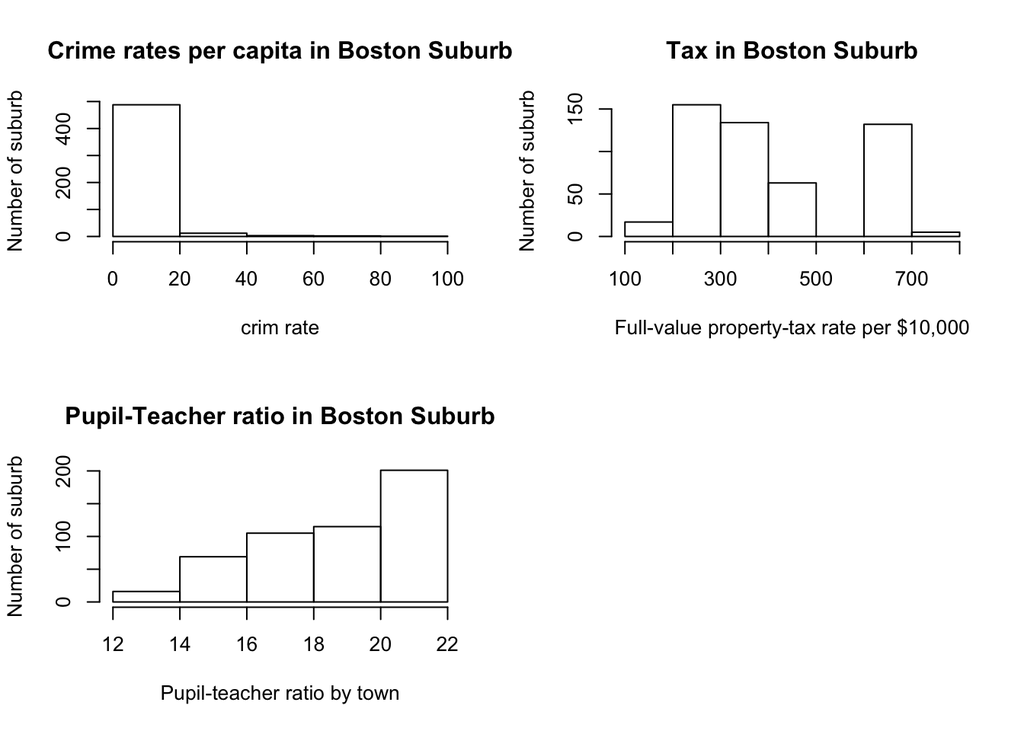

```r
par(mfrow=c(2,2))

hist(Boston$crim, main="Crime rates per capita in Boston Suburb",breaks= 5,xlab="crim rate", ylab="Number of suburb")
hist(Boston$tax, main="Tax in Boston Suburb",breaks= 5,xlab="Full-value property-tax rate per $10,000", ylab="Number of suburb")
hist(Boston$ptratio, main="Pupil-Teacher ratio in Boston Suburb",breaks= 5,xlab="Pupil-teacher ratio by town", ylab="Number of suburb")
```

Range for crim is 0.00632 to 88.97 with average of 3.6. i.e. average crim rate per capita in Boston is 3.6. Median of crime rate is like 26% and maximum value to 89% approximately, some neighborhoods have high crime rate. Most of neighborhoods fall in 0-10 crime rate ratio

From below output we can see,11% of houses have crime rate greater than 10%

```r
#get summary of crime rates above 10 based on graph data
?subset
selected_crime <- subset(Boston , Boston$crim > 10)
nrow(selected_crime)/nrow(Boston)
```

```
## [1] 0.1067194
```

```r
selected_tax <- subset(Boston, Boston$tax < 600)
nrow(selected_tax)/nrow(Boston)
```

```
## [1] 0.729249
```

Ptratio ranges between 12.60 to 22 with average of 18.46 Based on graph: There is linear graph between ptratio and number of houses i.e. a greater number of houses have more ptratio

Approx. 62% of houses have ptratio more than 18

```r
selected_ptratio <- subset(Boston, Boston$ptratio >18)
nrow(selected_ptratio)/nrow(Boston)
```

```
## [1] 0.6245059
```

### e) How many of the suburbs in this data set bound the Charles river?

```r
summary(Boston$chas)
```

```
##    Min. 1st Qu.  Median    Mean 3rd Qu.    Max.
## 0.00000 0.00000 0.00000 0.06917 0.00000 1.00000
```

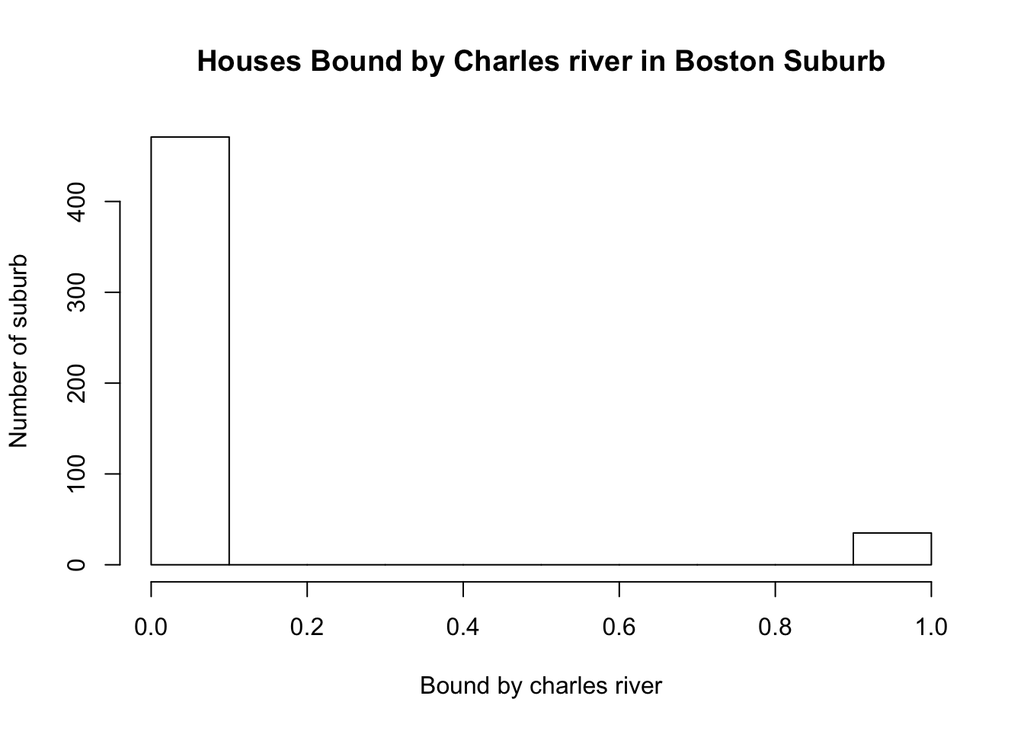

```r
hist(Boston$chas, main="Houses Bound by Charles river in Boston Suburb",xlab="Bound by charles river", ylab="Number of suburb")
```

```r
nrow(subset(Boston,Boston$chas == 1))
```

```
## [1] 35
```

### f) What is the median pupil-teacher ratio among the towns in this data set?

```r
summary(Boston)
```

```
##       crim                zn             indus            chas
##  Min.   : 0.00632   Min.   :  0.00   Min.   : 0.46   Min.   :0.00000
##  1st Qu.: 0.08204   1st Qu.:  0.00   1st Qu.: 5.19   1st Qu.:0.00000
##  Median : 0.25651   Median :  0.00   Median : 9.69   Median :0.00000
##  Mean   : 3.61352   Mean   : 11.36   Mean   :11.14   Mean   :0.06917
##  3rd Qu.: 3.67708   3rd Qu.: 12.50   3rd Qu.:18.10   3rd Qu.:0.00000
##  Max.   :88.97620   Max.   :100.00   Max.   :27.74   Max.   :1.00000
##       nox               rm             age              dis
##  Min.   :0.3850   Min.   :3.561   Min.   :  2.90   Min.   : 1.130
##  1st Qu.:0.4490   1st Qu.:5.886   1st Qu.: 45.02   1st Qu.: 2.100
##  Median :0.5380   Median :6.208   Median : 77.50   Median : 3.207
##  Mean   :0.5547   Mean   :6.285   Mean   : 68.57   Mean   : 3.795
##  3rd Qu.:0.6240   3rd Qu.:6.623   3rd Qu.: 94.08   3rd Qu.: 5.188
##  Max.   :0.8710   Max.   :8.780   Max.   :100.00   Max.   :12.127
##       rad              tax           ptratio          black
##  Min.   : 1.000   Min.   :187.0   Min.   :12.60   Min.   :  0.32
##  1st Qu.: 4.000   1st Qu.:279.0   1st Qu.:17.40   1st Qu.:375.38
##  Median : 5.000   Median :330.0   Median :19.05   Median :391.44
##  Mean   : 9.549   Mean   :408.2   Mean   :18.46   Mean   :356.67
##  3rd Qu.:24.000   3rd Qu.:666.0   3rd Qu.:20.20   3rd Qu.:396.23
##  Max.   :24.000   Max.   :711.0   Max.   :22.00   Max.   :396.90
##      lstat            medv
##  Min.   : 1.73   Min.   : 5.00
##  1st Qu.: 6.95   1st Qu.:17.02
##  Median :11.36   Median :21.20
##  Mean   :12.65   Mean   :22.53
##  3rd Qu.:16.95   3rd Qu.:25.00
##  Max.   :37.97   Max.   :50.00
```

### g) Which suburb of Boston has lowest median value of owner- occupied homes? What are the values of the other predictors for that suburb, and how do those values compare to the overall ranges for those predictors? Comment on your findings.

```r
#suburb of Boston with lowest median value of owner- occupied homes
attach(Boston)
orderd_medv_values = Boston[order(Boston$medv),]
orderd_medv_values[1,]
```

```
##        crim zn indus chas   nox    rm age    dis rad tax ptratio black
## 399 38.3518  0  18.1    0 0.693 5.453 100 1.4896  24 666    20.2 396.9
##     lstat medv
## 399 30.59    5
```

```r
detach(Boston)

summary(Boston)
```

```
##       crim                zn             indus            chas
##  Min.   : 0.00632   Min.   :  0.00   Min.   : 0.46   Min.   :0.00000
##  1st Qu.: 0.08204   1st Qu.:  0.00   1st Qu.: 5.19   1st Qu.:0.00000
##  Median : 0.25651   Median :  0.00   Median : 9.69   Median :0.00000
##  Mean   : 3.61352   Mean   : 11.36   Mean   :11.14   Mean   :0.06917
##  3rd Qu.: 3.67708   3rd Qu.: 12.50   3rd Qu.:18.10   3rd Qu.:0.00000
##  Max.   :88.97620   Max.   :100.00   Max.   :27.74   Max.   :1.00000
##       nox               rm             age              dis
##  Min.   :0.3850   Min.   :3.561   Min.   :  2.90   Min.   : 1.130
##  1st Qu.:0.4490   1st Qu.:5.886   1st Qu.: 45.02   1st Qu.: 2.100
##  Median :0.5380   Median :6.208   Median : 77.50   Median : 3.207
##  Mean   :0.5547   Mean   :6.285   Mean   : 68.57   Mean   : 3.795
##  3rd Qu.:0.6240   3rd Qu.:6.623   3rd Qu.: 94.08   3rd Qu.: 5.188
##  Max.   :0.8710   Max.   :8.780   Max.   :100.00   Max.   :12.127
##       rad              tax           ptratio          black
##  Min.   : 1.000   Min.   :187.0   Min.   :12.60   Min.   :  0.32
##  1st Qu.: 4.000   1st Qu.:279.0   1st Qu.:17.40   1st Qu.:375.38
##  Median : 5.000   Median :330.0   Median :19.05   Median :391.44
##  Mean   : 9.549   Mean   :408.2   Mean   :18.46   Mean   :356.67
##  3rd Qu.:24.000   3rd Qu.:666.0   3rd Qu.:20.20   3rd Qu.:396.23
##  Max.   :24.000   Max.   :711.0   Max.   :22.00   Max.   :396.90
##      lstat            medv
##  Min.   : 1.73   Min.   : 5.00
##  1st Qu.: 6.95   1st Qu.:17.02
##  Median :11.36   Median :21.20
##  Mean   :12.65   Mean   :22.53
##  3rd Qu.:16.95   3rd Qu.:25.00
##  Max.   :37.97   Max.   :50.00
```

```r
selected_crime_2 <- subset(Boston ,Boston$crim < 40)
nrow(selected_crime_2)/nrow(Boston)
```

```
## [1] 0.9881423
```

medv -> median value of owner-occupied home. Suburb 399 has lowest “medv” value.

### h) In this data set, how many of the suburbs average more than seven rooms per dwelling? More than eight rooms per dwelling? Comment on the suburbs that average more than eight rooms per dwelling.

```r
#suburbs average more than seven rooms per dwelling
suburbs_more_than_7 = subset(Boston, Boston$rm > 7)
nrow(suburbs_more_than_7)
```

```
## [1] 64
```

```r
#suburbs average more than seven rooms per dwelling
suburbs_more_than_8 = subset(Boston, Boston$rm > 8)
nrow(suburbs_more_than_8)
```

```
## [1] 13
```

```r
summary(suburbs_more_than_8)
```

```
##       crim               zn            indus             chas
##  Min.   :0.02009   Min.   : 0.00   Min.   : 2.680   Min.   :0.0000
##  1st Qu.:0.33147   1st Qu.: 0.00   1st Qu.: 3.970   1st Qu.:0.0000
##  Median :0.52014   Median : 0.00   Median : 6.200   Median :0.0000
##  Mean   :0.71879   Mean   :13.62   Mean   : 7.078   Mean   :0.1538
##  3rd Qu.:0.57834   3rd Qu.:20.00   3rd Qu.: 6.200   3rd Qu.:0.0000
##  Max.   :3.47428   Max.   :95.00   Max.   :19.580   Max.   :1.0000
##       nox               rm             age             dis
##  Min.   :0.4161   Min.   :8.034   Min.   : 8.40   Min.   :1.801
##  1st Qu.:0.5040   1st Qu.:8.247   1st Qu.:70.40   1st Qu.:2.288
##  Median :0.5070   Median :8.297   Median :78.30   Median :2.894
##  Mean   :0.5392   Mean   :8.349   Mean   :71.54   Mean   :3.430
##  3rd Qu.:0.6050   3rd Qu.:8.398   3rd Qu.:86.50   3rd Qu.:3.652
##  Max.   :0.7180   Max.   :8.780   Max.   :93.90   Max.   :8.907
##       rad              tax           ptratio          black
##  Min.   : 2.000   Min.   :224.0   Min.   :13.00   Min.   :354.6
##  1st Qu.: 5.000   1st Qu.:264.0   1st Qu.:14.70   1st Qu.:384.5
##  Median : 7.000   Median :307.0   Median :17.40   Median :386.9
##  Mean   : 7.462   Mean   :325.1   Mean   :16.36   Mean   :385.2
##  3rd Qu.: 8.000   3rd Qu.:307.0   3rd Qu.:17.40   3rd Qu.:389.7
##  Max.   :24.000   Max.   :666.0   Max.   :20.20   Max.   :396.9
##      lstat           medv
##  Min.   :2.47   Min.   :21.9
##  1st Qu.:3.32   1st Qu.:41.7
##  Median :4.14   Median :48.3
##  Mean   :4.31   Mean   :44.2
##  3rd Qu.:5.12   3rd Qu.:50.0
##  Max.   :7.44   Max.   :50.0
```

Summary of subset of dataset with average more than 8 rooms per dwelling (suburbs_more_than_8):

```r
summary(suburbs_more_than_8)[4,]
```

```
##                crim                  zn               indus
## "Mean   :0.71879  "   "Mean   :13.62  "  "Mean   : 7.078  "
##                chas                 nox                  rm
##  "Mean   :0.1538  "  "Mean   :0.5392  "   "Mean   :8.349  "
##                 age                 dis                 rad
##   "Mean   :71.54  "   "Mean   :3.430  "  "Mean   : 7.462  "
##                 tax             ptratio               black
##   "Mean   :325.1  "   "Mean   :16.36  "   "Mean   :385.2  "
##               lstat                medv
##    "Mean   :4.31  "    "Mean   :44.2  "
```

Mean of complete dataset of Boston:

```r
summary(Boston)[4,]
```

```
##                 crim                   zn                indus
## "Mean   : 3.61352  "   "Mean   : 11.36  "    "Mean   :11.14  "
##                 chas                  nox                   rm
##  "Mean   :0.06917  "   "Mean   :0.5547  "    "Mean   :6.285  "
##                  age                  dis                  rad
##   "Mean   : 68.57  "   "Mean   : 3.795  "   "Mean   : 9.549  "
##                  tax              ptratio                black
##    "Mean   :408.2  "    "Mean   :18.46  "   "Mean   :356.67  "
##                lstat                 medv
##    "Mean   :12.65  "    "Mean   :22.53  "
```